# lab2

Steve Newns

May 21, 2018

## Correlation and regression using the Lahman database for baseball

`Lahman` package = gold mine for statisticians interested in studying baseball

Below = explore parts of `Lahman` package + also link to the statistical concepts in a bivariate analysis, including correlation, regression, and R-squared.

```r
library(Lahman) # 25 datasets
library(mosaic)
library(ggplot2)
library(tidyverse)

# list of the data frames available
LahmanData %>%
  arrange(desc(nobs))
```

```
##                   file      class   nobs nvar                     title
## 1             Fielding data.frame 167938   18            Fielding table
## 2              Batting data.frame  99846   22             Batting table
## 3          Appearances data.frame  99466   21         Appearances table
## 4             Pitching data.frame  43330   30            Pitching table
## 5             Salaries data.frame  24758    5            Salaries table
## 6               Master data.frame  18589   26              Master table
## 7       CollegePlaying data.frame  17350    3      CollegePlaying table
## 8           FieldingOF data.frame  12028    6          FieldingOF table
## 9         FieldingPost data.frame  11924   17         FieldingPost data
## 10         BattingPost data.frame  11294   22         BattingPost table
## 11  AwardsSharePlayers data.frame   6705    7  AwardsSharePlayers table
## 12       AwardsPlayers data.frame   6026    6       AwardsPlayers table
## 13         AllstarFull data.frame   4993    8         AllstarFull table
## 14        PitchingPost data.frame   4945   30        PitchingPost table
## 15          HallOfFame data.frame   4088    9  Hall of Fame Voting Data
## 16            Managers data.frame   3370   10            Managers table
## 17               Teams data.frame   2775   48               Teams table
## 18             Schools data.frame   1207    5             Schools table
## 19 AwardsShareManagers data.frame    401    7 AwardsShareManagers table
## 20          SeriesPost data.frame    298    9          SeriesPost table
## 21      AwardsManagers data.frame    171    6      AwardsManagers table
## 22     TeamsFranchises data.frame    120    4      TeamFranchises table
## 23        ManagersHalf data.frame     93   10        ManagersHalf table
## 24           TeamsHalf data.frame     52   10           TeamsHalf table
```

*1. Which data frames in the Lahman package has the largest number of observations? Which have the fewest?*

- most = `Fielding`, least = `TeamsHalf`

```r
data(Teams)
head(Teams)
```

```
##   yearID lgID teamID franchID divID Rank  G Ghome  W  L DivWin WCWin LgWin
## 1   1871   NA    BS1      BNA  <NA>    3 31    NA 20 10   <NA>  <NA>     N
## 2   1871   NA    CH1      CNA  <NA>    2 28    NA 19  9   <NA>  <NA>     N
## 3   1871   NA    CL1      CFC  <NA>    8 29    NA 10 19   <NA>  <NA>     N
## 4   1871   NA    FW1      KEK  <NA>    7 19    NA  7 12   <NA>  <NA>     N
## 5   1871   NA    NY2      NNA  <NA>    5 33    NA 16 17   <NA>  <NA>     N
## 6   1871   NA    PH1      PNA  <NA>    1 28    NA 21  7   <NA>  <NA>     Y
##   WSWin   R   AB   H X2B X3B HR BB SO SB CS HBP SF  RA  ER  ERA CG SHO SV
## 1  <NA> 401 1372 426  70  37  3 60 19 73 NA  NA NA 303 109 3.55 22   1  3
## 2  <NA> 302 1196 323  52  21 10 60 22 69 NA  NA NA 241  77 2.76 25   0  1
## 3  <NA> 249 1186 328  35  40  7 26 25 18 NA  NA NA 341 116 4.11 23   0  0
## 4  <NA> 137  746 178  19   8  2 33  9 16 NA  NA NA 243  97 5.17 19   1  0
## 5  <NA> 302 1404 403  43  21  1 33 15 46 NA  NA NA 313 121 3.72 32   1  0
## 6  <NA> 376 1281 410  66  27  9 46 23 56 NA  NA NA 266 137 4.95 27   0  0
##   IPouts  HA HRA BBA SOA   E DP    FP                    name
```

[output cut: 20 more lines]

```r
tail(Teams)
```

```
##      yearID lgID teamID franchID divID Rank   G Ghome  W  L DivWin WCWin
## 2830   2016   NL    SFN      SFG     W    2 162    81 87 75      N     Y
## 2831   2016   NL    SLN      STL     C    2 162    81 86 76      N     N
## 2832   2016   AL    TBA      TBD     E    5 162    81 68 94      N     N
## 2833   2016   AL    TEX      TEX     W    1 162    81 95 67      Y     N
## 2834   2016   AL    TOR      TOR     E    2 162    81 89 73      N     Y
## 2835   2016   NL    WAS      WSN     E    1 162    81 95 67      Y     N
##      LgWin WSWin   R   AB    H X2B X3B  HR  BB   SO  SB CS HBP SF  RA  ER
## 2830     N     N 715 5565 1437 280  54 130 572 1107  79 36  42 46 631 593
## 2831     N     N 779 5548 1415 299  32 225 526 1318  35 26  70 41 712 656
## 2832     N     N 672 5481 1333 288  32 216 449 1482  60 37  69 28 713 665
## 2833     N     N 765 5525 1446 257  23 215 436 1220  99 36  70 40 757 700
## 2834     N     N 759 5479 1358 276  18 221 632 1362  54 24  55 40 666 613
## 2835     N     N 763 5490 1403 268  29 203 536 1252 121 39  64 63 612 570
##       ERA CG SHO SV IPouts   HA HRA BBA  SOA   E  DP    FP
```

[output cut: 20 more lines]

```r
teams_1 <- Teams %>% filter(yearID >= 1970)
```

- 2.1 Write a command to generate the names of the Teams data.
- 2.2 Write a command that gives you the dimensions of the Teams data.
- 2.3 Identify the observation in row 500 and column 10.

```r
names(teams_1)
```

```
##  [1] "yearID"         "lgID"           "teamID"         "franchID"
##  [5] "divID"          "Rank"           "G"              "Ghome"
##  [9] "W"              "L"              "DivWin"         "WCWin"
## [13] "LgWin"          "WSWin"          "R"              "AB"
## [17] "H"              "X2B"            "X3B"            "HR"
## [21] "BB"             "SO"             "SB"             "CS"
## [25] "HBP"            "SF"             "RA"             "ER"
## [29] "ERA"            "CG"             "SHO"            "SV"
## [33] "IPouts"         "HA"             "HRA"            "BBA"
## [37] "SOA"            "E"              "DP"             "FP"
## [41] "name"           "park"           "attendance"     "BPF"
## [45] "PPF"            "teamIDBR"       "teamIDlahman45" "teamIDretro"
```

```r
dim(teams_1)
```

```
## [1] 1294   48
```

```r
teams_1[500,10]
```

```
## [1] 88
```

Create a few missing team-level variables needed for the lab: `X1B` (# of singles), `TB` (total bases), `RC` (runs created), and `RC_new` (a newer runs created formula)

```r
teams_1 <- teams_1 %>%
  mutate(X1B = H - X2B - X3B - HR,
         TB = X1B + 2*X2B + 3*X3B + 4*HR,
         RC = (H+BB)*TB/(AB+BB),
         RC_new = (H+BB-CS)*(TB+.55*SB)/(AB+BB))
```

1st formula for RC = the basic one, while the 2nd uses a tweak for SB.

### Bivariate analysis

#### Correlation and scatter plots

Using teams_1, quantify the strength, shape, + direction of the association between RC + runs.

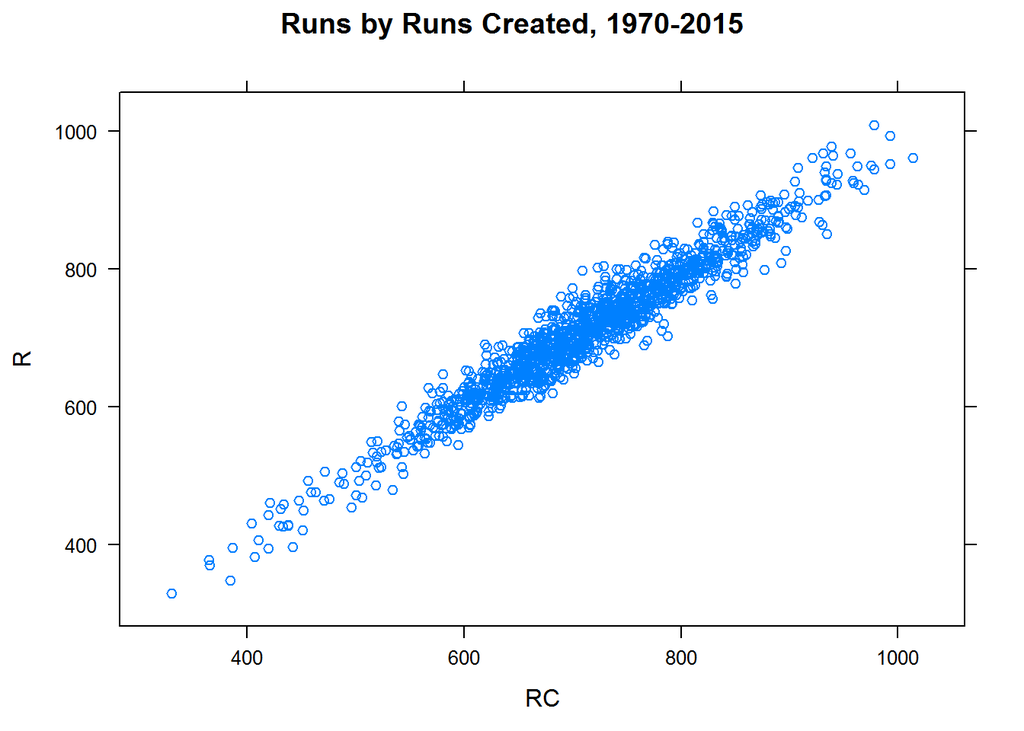

```r
lattice::xyplot(R ~ RC, teams_1, main="Runs by Runs Created, 1970-2015")
```

```r
paste0('r (RC): ',cor(R ~ RC, data = teams_1))
```

```
## [1] "r (RC): 0.967736609433717"
```

```r
paste0('R2 (RC): ',cor(R ~ RC, data = teams_1)**2)
```

```
## [1] "R2 (RC): 0.936514145238266"
```

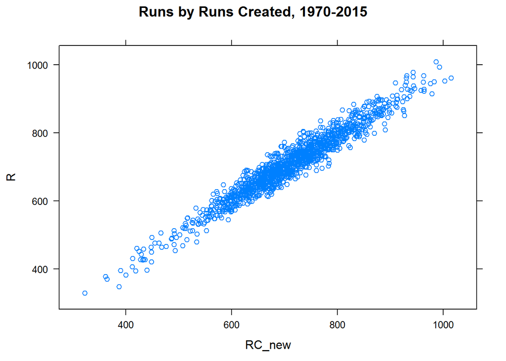

```r
lattice::xyplot(R ~ RC_new, teams_1, main="Runs by Runs Created, 1970-2015")
```

```r
paste0('r (RC_new): ',cor(R ~ RC_new, data = teams_1))
```

```
## [1] "r (RC_new): 0.968985464112183"
```

```r
paste0('R2 (RC_new): ',cor(R ~ RC_new, data = teams_1)**2)
```

```
## [1] "R2 (RC_new): 0.938932829660703"
```

**3. Which variable - RC or RC.new - shows a stronger link with runs? What does this entail about the updated stolen bases formula?**

- `Rc_new` shows a slightly stronger positive association with `R`, which suggest `SB` plays a factor in increasing the number of `R`

Now, ID some additional ways of quantifying the association between 2 variables: look at the relationship between a team’s HR + its R

```r
paste0('r (R~HR): ',cor(R ~ HR, data = teams_1))
```

```
## [1] "r (R~HR): 0.752204505033359"
```

```r
paste0('R2 (R~HR): ',cor(R ~ HR, data = teams_1)**2)
```

```
## [1] "R2 (R~HR): 0.565811617392481"
```

**4. Interpret the correlation coefficient and the R-squared values between home runs and runs.**

- Only about 57% of the variability in `R` is explained by `HR`, and the $r$ values of .75 suggests a strong positive relationship between `HR` and `R`

From intro stats, remember **simple linear regression (SLR)**: $\hat{y}_i = \hat{\beta_0} + \hat{\beta_1}*x_i$, where $\hat{y}_i$ = predicted value of an outcome variable given $x_i$, while $\hat{\beta_p}$ = estimated parameters = intercepts and slopes

In our example, we can plug in our variable names: $\hat{R}_i = \hat{\beta_0} + \hat{\beta_1}HR_i$

**5. Make a scatter plot of R as a function of HR. Using the function, make educated guesses for $\hat{\beta_0}$ and $\hat{\beta_1}$**

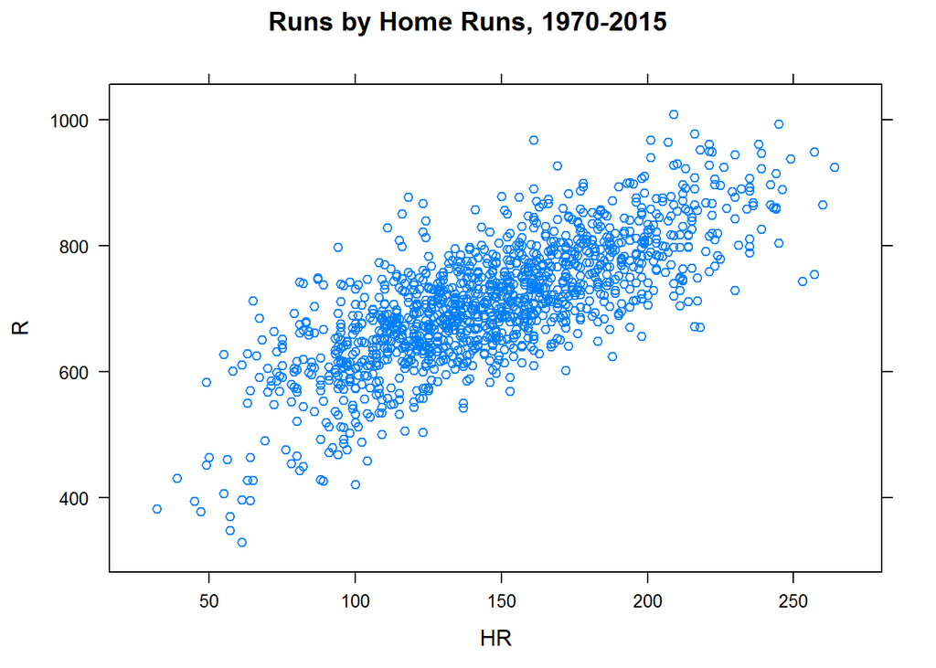

```r
lattice::xyplot(R ~ HR, teams_1, main="Runs by Home Runs, 1970-2015")
```

- guess for $\hat{\beta_0}$ = 500, for $\hat{\beta_1}$ = 1.5

Fortunately, we don’t *have* to make educated guesses.

```r
fit_1 <- lm(R ~ HR, teams_1)
msummary(fit_1)
```

```
##              Estimate Std. Error t value Pr(>|t|)
## (Intercept) 442.05664    6.76430   65.35   <2e-16 ***
## HR            1.82714    0.04453   41.03   <2e-16 ***
##
## Residual standard error: 64.9 on 1292 degrees of freedom
## Multiple R-squared:  0.5658, Adjusted R-squared:  0.5655
## F-statistic:  1684 on 1 and 1292 DF,  p-value: < 2.2e-16
```

- $\hat{R}_i = 442.05664 + 1.82714HR_i$

**7. Interpret both the intercept and the slope (for HR) in the estimated regression equation. Is the intercept a useful term here?**

- This intercept suggests teams would score 442 runs even if they hit no home runs, but the intercept really just serves to set the y-axis start.
- The slope for `HR` suggests that for each `HR`, teams score, on average, 1.82 more runs

**8. Estimate the number of runs that a team with 250 home runs would score.**

```r
442.05664 + 1.82714*250
```

```
## [1] 898.8416
```

Can also plot an estimated regression line, assuming we’ve already stored a linear model.

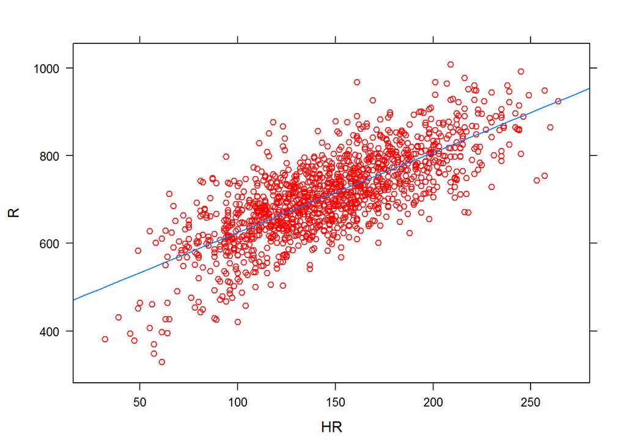

```r
plotModel(fit_1,col='red')
```

R knows `fit_1` contains a linear model of `R` as a function of `HR`. Hopefully this reflects the line of best fit you would’ve drawn by hand.

**9. Is the link between home runs and runs significant? How can you tell?**

```r
msummary(fit_1)
```

```
##              Estimate Std. Error t value Pr(>|t|)
## (Intercept) 442.05664    6.76430   65.35   <2e-16 ***
## HR            1.82714    0.04453   41.03   <2e-16 ***
##
## Residual standard error: 64.9 on 1292 degrees of freedom
## Multiple R-squared:  0.5658, Adjusted R-squared:  0.5655
## F-statistic:  1684 on 1 and 1292 DF,  p-value: < 2.2e-16
```

- Yes, which is signified via its’ *** rating in the table and it’s $p$-value being much less than .05

Related note on significance testing: turn attention to another variable with a lesser link to runs, `SB`

```r
fit_2 <- lm(R ~ SB, teams_1)
msummary(fit_2)
```

```
##              Estimate Std. Error t value Pr(>|t|)
## (Intercept) 690.80275    7.64706  90.336  < 2e-16 ***
## SB            0.17957    0.06839   2.626  0.00875 **
##
## Residual standard error: 98.24 on 1292 degrees of freedom
## Multiple R-squared:  0.005308,   Adjusted R-squared:  0.004538
## F-statistic: 6.894 on 1 and 1292 DF,  p-value: 0.008751
```

```r
cor.test(teams_1$R, teams_1$SB)
```

```
##
##  Pearson's product-moment correlation
##
## data:  x and y
## t = 2.6256, df = 1292, p-value = 0.008751
## alternative hypothesis: true correlation is not equal to 0
## 95 percent confidence interval:
##  0.01843146 0.12684416
## sample estimates:
##        cor
## 0.07285302
```

In the 1st output, the **relative significance of the slope parameter** $\hat{\beta_1}$ (as judged by a $p$−value = 0.00875) is identical to the **relative significance of the test for the significance of the correlation coefficient** ($p$−value = 0.008751)

**10. Use a similar code to determine if there is there a significant linear association between team runs and the number of times that team was caught stealing?**

```r
fit_3 <- lm(R ~ CS, teams_1)
msummary(fit_3)
```

```
##             Estimate Std. Error t value Pr(>|t|)
## (Intercept) 742.5280     8.2209   90.32  < 2e-16 ***
## CS           -0.6837     0.1609   -4.25 2.29e-05 ***
##
## Residual standard error: 97.82 on 1292 degrees of freedom
## Multiple R-squared:  0.01379,    Adjusted R-squared:  0.01302
## F-statistic: 18.06 on 1 and 1292 DF,  p-value: 2.293e-05
```

```r
cor.test(teams_1$R, teams_1$CS)
```

```
##
##  Pearson's product-moment correlation
##
## data:  x and y
## t = -4.2498, df = 1292, p-value = 2.293e-05
## alternative hypothesis: true correlation is not equal to 0
## 95 percent confidence interval:
##  -0.17081702 -0.06332572
## sample estimates:
##        cor
## -0.1174153
```

### Analyzing several variables simultaneously

Now look at how one would analyze a subset of variables to judge which are most strongly associated with team success. 1st, reduce data set from several dozen columns to only the ones we’re interested in studying.

```r
teams_3 <- teams_1 %>% select(R, RC_new, RC, RA, HR, SO, attendance)

# calculate pairwise correlation coefficient between each variable.
(cor_matrix <- round(cor(teams_3),3))
```

```
##                R RC_new    RC    RA    HR    SO attendance
## R          1.000  0.969 0.968 0.493 0.752 0.285      0.467
## RC_new     0.969  1.000 0.999 0.505 0.777 0.311      0.501
## RC         0.968  0.999 1.000 0.512 0.781 0.302      0.490
## RA         0.493  0.505 0.512 1.000 0.432 0.347      0.049
## HR         0.752  0.777 0.781 0.432 1.000 0.515      0.471
## SO         0.285  0.311 0.302 0.347 0.515 1.000      0.353
## attendance 0.467  0.501 0.490 0.049 0.471 0.353      1.000
```

**11. Of the variables listed, which boast the strongest and weakest correlations with runs scored?**

- Strongest: `{RC, RC_new, HR}`
- Weakest: `{SO, attendance, RA}`

As is usual in the case w/ observational data like this, strong links between 2 variables do *NOT* entail that 1 variable causes the other. While hitting `HR`s will likely cause teams to score more `R`, it is not neccessarily the case that higher attendence causes teams to score more `R`s.

**12. Think of 1 reason why attendence and runs are significantly correlated besides saying that attendence causes teams to score more runs.**

- Teams that score more may be better teams, and better teams tend to draw a larger crowd

### Plotting correlations

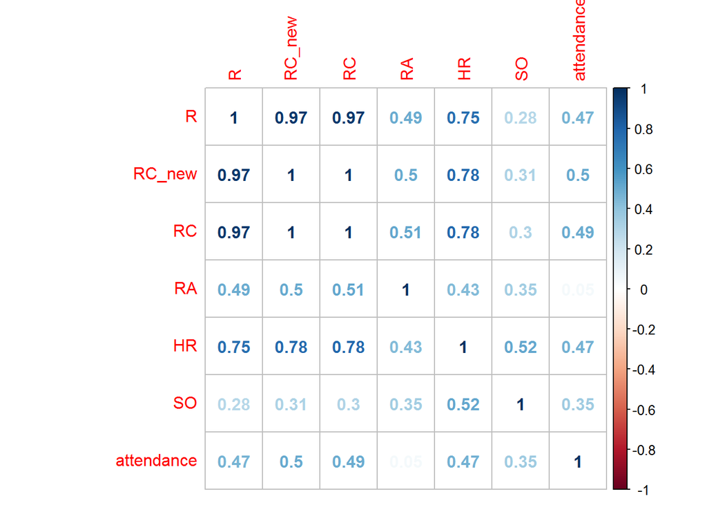

```r
library(corrplot)
corrplot(cor_matrix, method="number")
```

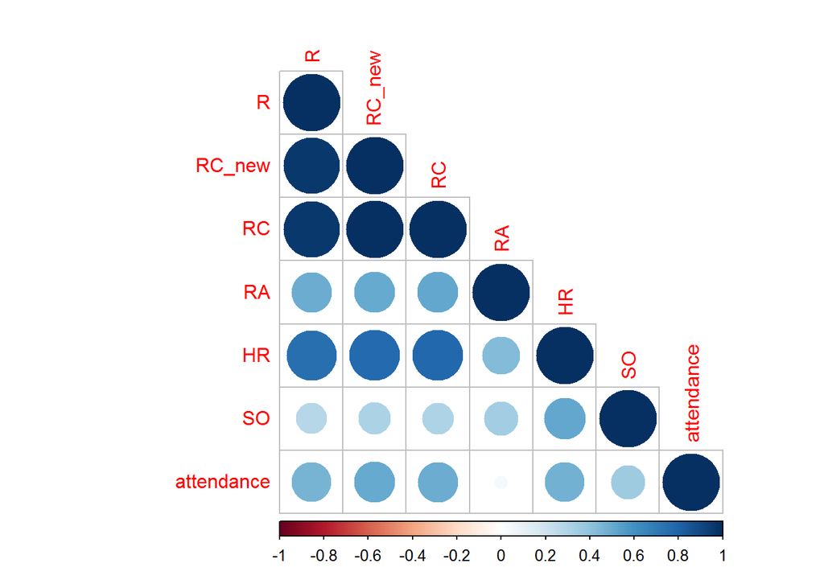

```r
corrplot(cor_matrix, method="circle", type = "lower")
```

### Better team metrics: on base, slugging, OPS

Perhaps other functions of traditional baseball stat are worth looking at: on base percentage (`OBP`), slugging percentage (`SLG`), and `OPS`, = sum of `OBP` and `SLG`.

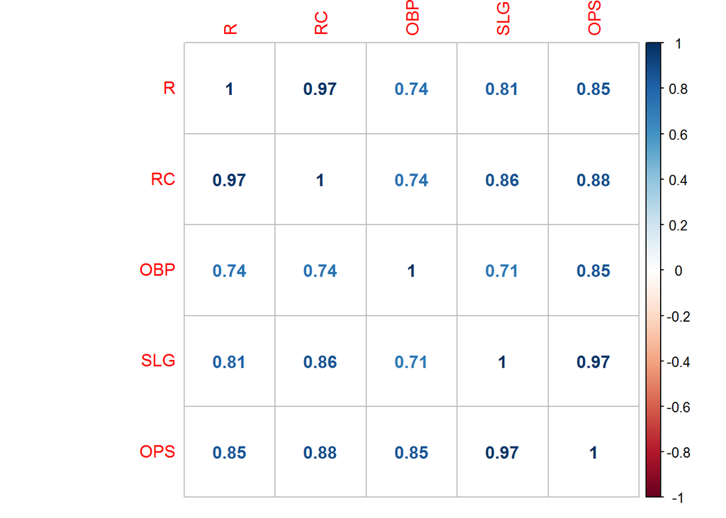

```r
teams_1 <- teams_1 %>%
  mutate(OBP = (H + BB)/(AB + BB),
         SLG = (X1B + 2*X2B + 3*X3B + 4*HR)/AB,
         OPS = OBP + SLG)
cor_matrix <- round(cor(select(teams_1, R, RC, OBP, SLG, OPS)),2)
corrplot(cor_matrix, method="number")
```

### Repeatability

```r
teams_2 <- teams_1 %>%
  arrange(franchID, yearID) %>%
  group_by(franchID) %>%
  mutate(next_R = lead(RC))
head(teams_2)
```

```
## # A tibble: 6 x 56
## # Groups:   franchID [1]
##   yearID lgID  teamID franchID divID  Rank     G Ghome     W     L DivWin
##    <int> <fct> <fct>  <fct>    <chr> <int> <int> <int> <int> <int> <chr>
## 1   1970 AL    CAL    ANA      W         3   162    81    86    76 N
## 2   1971 AL    CAL    ANA      W         4   162    81    76    86 N
## 3   1972 AL    CAL    ANA      W         5   155    80    75    80 N
## 4   1973 AL    CAL    ANA      W         4   162    81    79    83 N
## 5   1974 AL    CAL    ANA      W         6   163    81    68    94 N
## 6   1975 AL    CAL    ANA      W         6   161    81    72    89 N
## # ... with 45 more variables: WCWin <chr>, LgWin <chr>, WSWin <chr>,
## #   R <int>, AB <int>, H <int>, X2B <int>, X3B <int>, HR <int>, BB <int>,
## #   SO <int>, SB <int>, CS <int>, HBP <int>, SF <int>, RA <int>, ER <int>,
## #   ERA <dbl>, CG <int>, SHO <int>, SV <int>, IPouts <int>, HA <int>,
## #   HRA <int>, BBA <int>, SOA <int>, E <int>, DP <int>, FP <dbl>,
## #   name <chr>, park <chr>, attendance <int>, BPF <int>, PPF <int>,
## #   teamIDBR <chr>, teamIDlahman45 <chr>, teamIDretro <chr>, X1B <int>,
## #   TB <dbl>, RC <dbl>, RC_new <dbl>, OBP <dbl>, SLG <dbl>, OPS <dbl>,
## #   next_R <dbl>
```

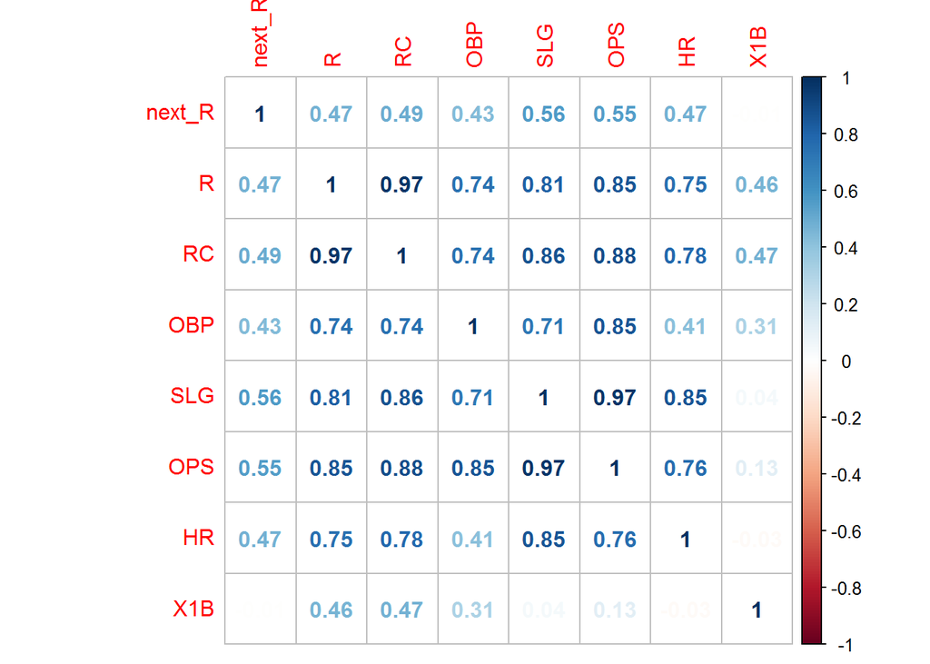

```r
cor_matrix <- round(cor(select(ungroup(teams_2), next_R, R, RC, OBP, SLG, OPS, HR, X1B),
                  use="pairwise.complete.obs"),2)
corrplot(cor_matrix, method="number")
```

**14. Which variables appear to be the best at predicting a team’s runs scored in the following year? Which appears to be the worst?**

- Best = `{SLG, OPS}`, Worst = `{X1B, OBP}`

**15. Related: Compare the correlation of singles (`X1B`) to `next_R` and `R`, as well as `HR` to `next_R` and `R`. Think carefully about how this would impact your recommendations of how to build a team. Which measures should be looked at most closely? Which measures appear to be mostly noise?**

**16. For fun: Go to the Shiny app (here)[https://istats.shinyapps.io/guesscorr/]. Take a few guesses, and then click View scatterplot of correlation between your guesses and actual correlation. How good are you at guessing the correlation coefficient?**